# Sequences & Series

### Series Expansion

Computing a series expansion using SymPy is pretty straightforward. Consider the following equation:

$f(x) = \frac{1}{x + 1}$

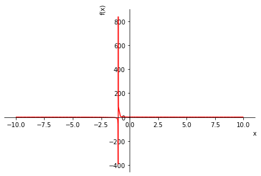

```python
from sympy import *
init_session(quiet = True)

%matplotlib inline

f_x = 1 / (x + 1)
plt = plotting.plot(f_x, line_color='red')
```

For example, consider the series expansion of $f(x)$. By default, the `series` method computes the expansion around the point $x = x_0$ and order $x^n$, with the arguments `x0=0` and `n=6`.

```python
f_x.series(x)
```

$\displaystyle 1 - x + x^{2} - x^{3} + x^{4} - x^{5} + O\left(x^{6}\right)$

To remove the Landau order term, use the `removeO` method:

```python
f_x.series(x).removeO()
```

$\displaystyle - x^{5} + x^{4} - x^{3} + x^{2} - x + 1$

The limit points and order can also be updated:

```python
f_x.series(x, x0=1, n=3).removeO()
```

$\displaystyle - \frac{x}{4} + \frac{\left(x - 1\right)^{2}}{8} + \frac{3}{4}$

### Convergence Testing

A common problem in calculus is testing whether a series is convergent (and absolutely convergent) or divergent. SymPy has methods to conduct these tests: `is_comvergent` and `is_absolutely_convergent`.

Consider the following series:

$g(x) = \sum_{n=1}^{\infty} \frac{1}{(n+1)(n+2)}$

To write this expression using SymPy, you can use the `Sum()` function, with the expression as the first argument and a tuple in the following format as the second: `(variable, start, end)`

Then, use the `is_convergent` and `is_absolutely_convergent` methods.

```python
g_x = 1 / ((n + 1) * (n + 2))

print(Sum(g_x, (n, 1, oo)).is_convergent())
print(Sum(g_x, (n, 1, oo)).is_absolutely_convergent())
```

```
True
True
```

Addional documentation can be found at the official SymPy website:  
https://docs.sympy.org/latest/tutorial/calculus.html#series-expansion  
https://docs.sympy.org/latest/modules/concrete.html#concrete-class-reference